# Assignment 06 : Hierarchical Clustering

Dibakar Bhowal

2025-04-14

```r
library(dplyr)
```

```r
library(ggplot2)
library(cluster)
library(factoextra)
library(fpc)
library(e1071)
library(tinytex)
```

```r
# Loading Dataset
Wine <- read.csv("/home/mukta/Downloads/Wine-Clustering-HC.csv")
```

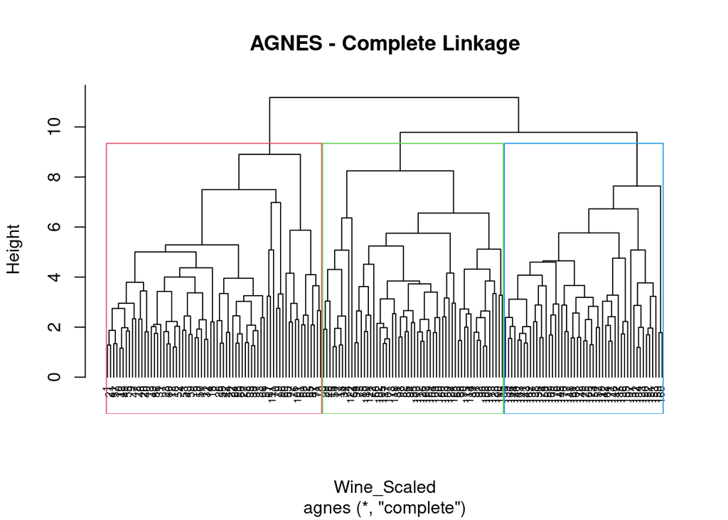

```r
# Q1-A:
# Preparation & Normalization
Wine_Numeric <- Wine[, 1:13]
Wine_Scaled <- scale(Wine_Numeric)

# AGNES clustering with various methods

# Complete Linkage
Agnes_Complete <- agnes(Wine_Scaled, method = "complete")
pltree(Agnes_Complete, main = "AGNES - Complete Linkage", hang = -1, cex = 0.6)
rect.hclust(as.hclust(Agnes_Complete), k = 3, border = 2:4)
```

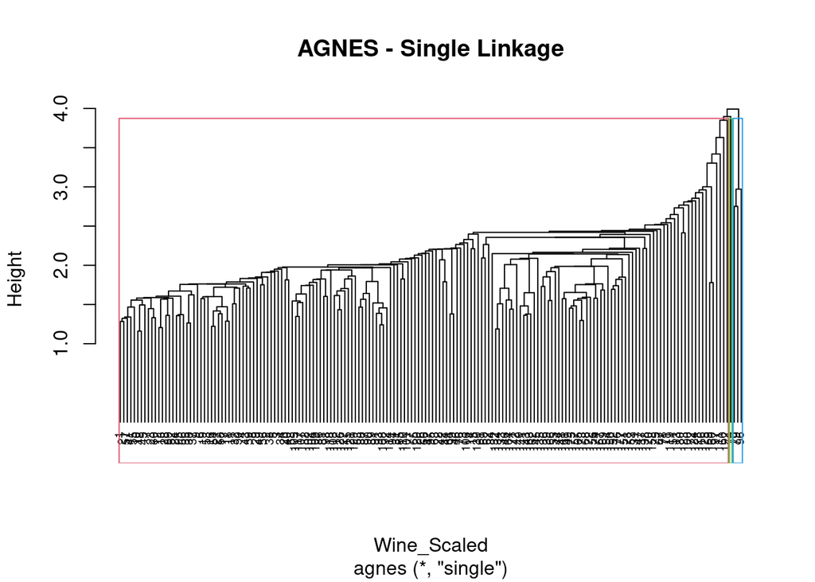

```r
# Single Linkage
Agnes_Single <- agnes(Wine_Scaled, method = "single")
pltree(Agnes_Single, main = "AGNES - Single Linkage", hang = -1, cex = 0.6)
rect.hclust(as.hclust(Agnes_Single), k = 3, border = 2:4)
```

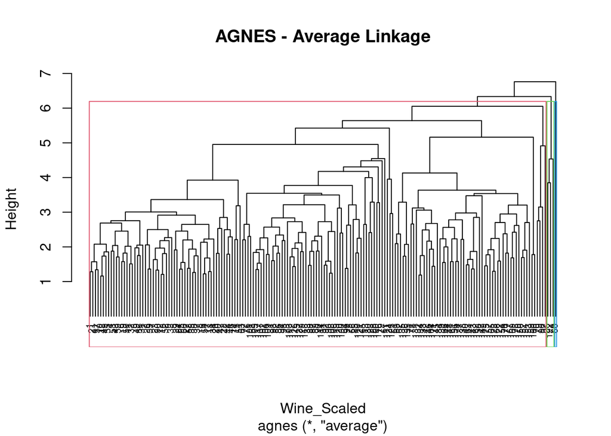

```r
# Average Linkage
Agnes_Average <- agnes(Wine_Scaled, method = "average")
pltree(Agnes_Average, main = "AGNES - Average Linkage", hang = -1, cex = 0.6)
rect.hclust(as.hclust(Agnes_Average), k = 3, border = 2:4)
```

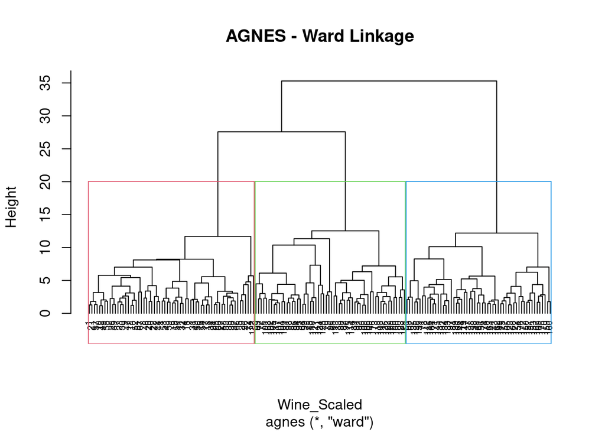

```r
# Ward Linkage
Agnes_Ward <- agnes(Wine_Scaled, method = "ward")
pltree(Agnes_Ward, main = "AGNES - Ward Linkage", hang = -1, cex = 0.6)
rect.hclust(as.hclust(Agnes_Ward), k = 3, border = 2:4)
```

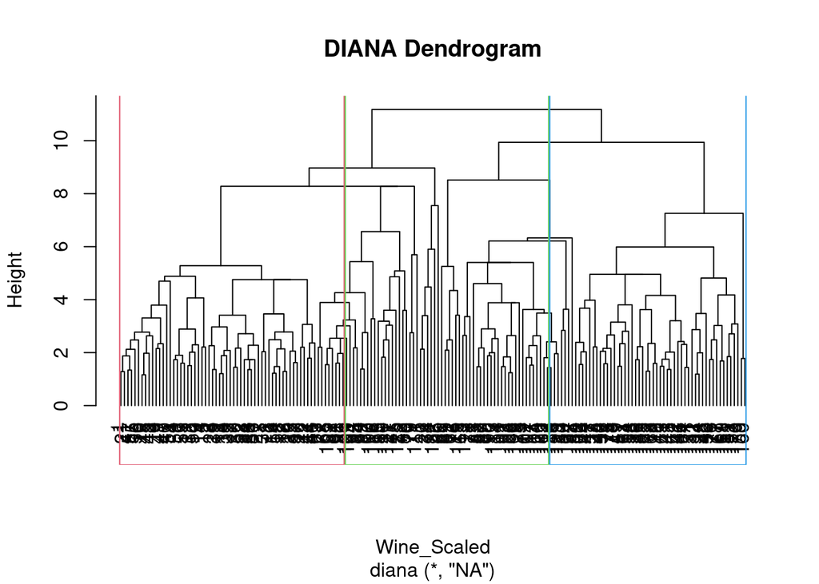

```r
# DIANA clustering
Diana_Model <- diana(Wine_Scaled)
pltree(Diana_Model, main = "DIANA Dendrogram", hang = -1)
rect.hclust(as.hclust(Agnes_Ward), k = 3, border = 2:4)
```

```r
# Q1-B:
Agnes_Ward$ac  # Agglomerative coefficient (AC)
```

```
## [1] 0.9419172
```

```r
Diana_Model$dc # Divisive coefficient (DC)
```

```
## [1] 0.8000096
```

# Interpretation : We can see that AGNES AC is higher than DIANA DC, indicating that AGNES provides a more cohesive clustering structure. We are using Agnes_Ward as from the visuals it’s apparent that this methods clustering structure is the most coherent.

```r
# Q2-A:
# Median Alcohol by Alcohol_Level
Median_Alcohol <- Wine %>%
  group_by(Alcohol_Level) %>%
  summarise(Median_Alcohol = median(Alcohol, na.rm = TRUE))

# Median Ash by Ash_Content

Median_Ash <- Wine %>%
  group_by(Ash_Content) %>%
  summarise(Median_Ash = median(Ash, na.rm = TRUE))

# Median Color_Intensity by Color_Intensity_Group
Median_Color_Intensity <- Wine %>%
  group_by(Color_Intensity_Group) %>%
  summarise(Median_Color_Intensity = median(Color_Intensity, na.rm = TRUE))
```

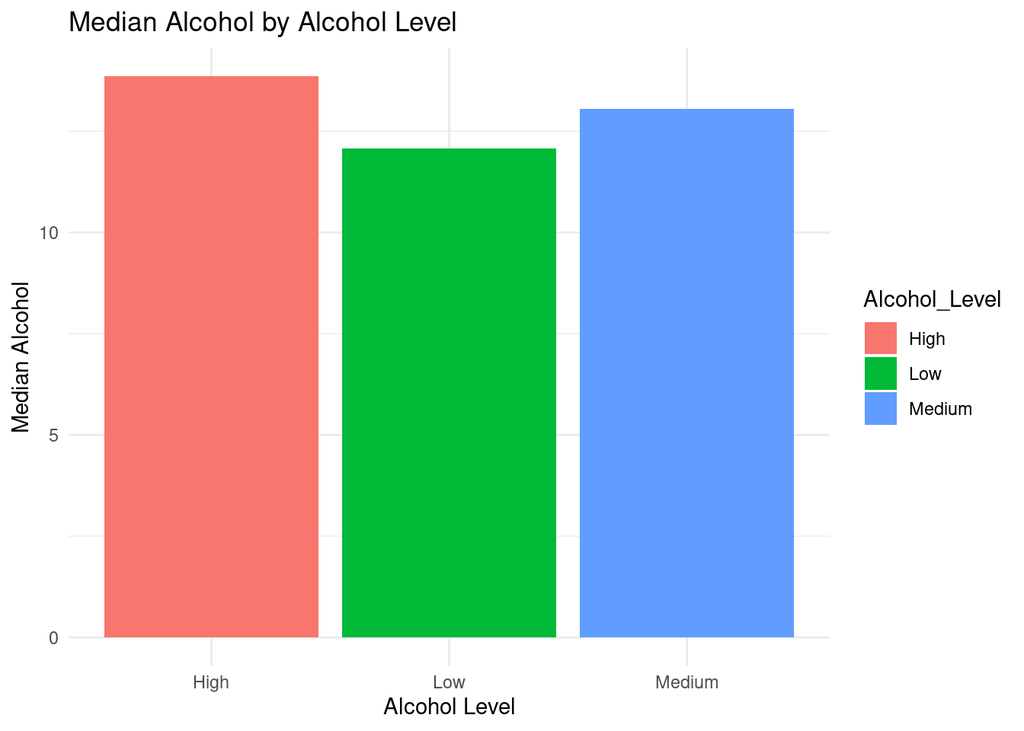

```r
# Q2-B:
# Alcohol
ggplot(Median_Alcohol, aes(x = Alcohol_Level, y = Median_Alcohol, fill = Alcohol_Level)) +
  geom_bar(stat = "identity") +
  labs(title = "Median Alcohol by Alcohol Level", y = "Median Alcohol", x = "Alcohol Level") +
  theme_minimal()
```

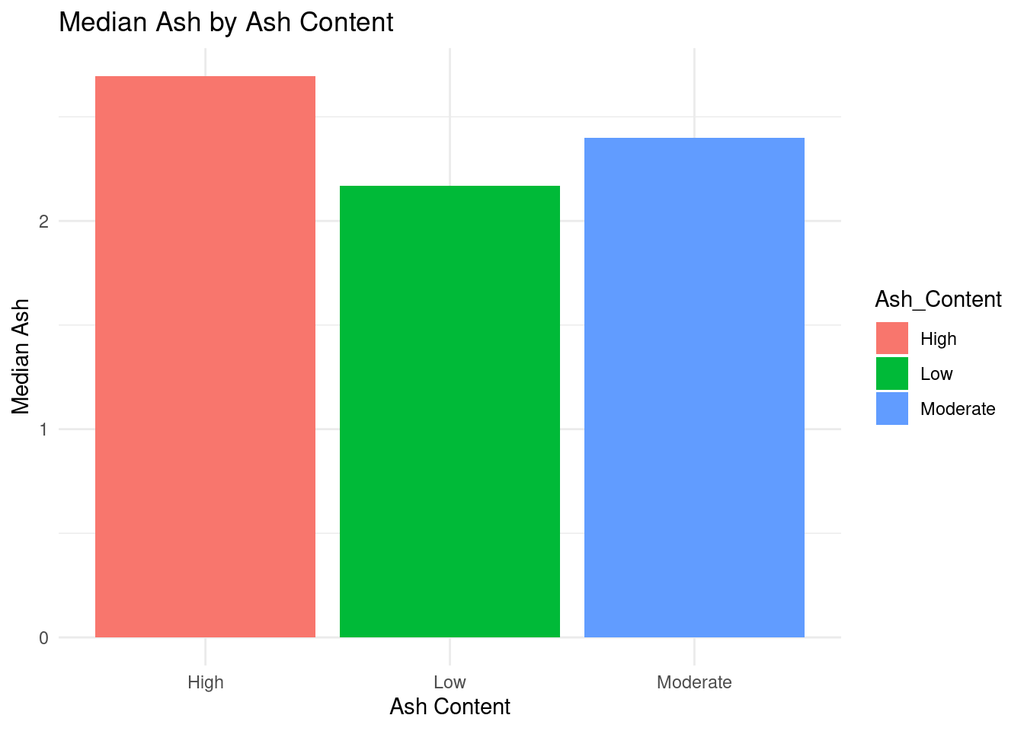

```r
# Ash
ggplot(Median_Ash, aes(x = Ash_Content, y = Median_Ash, fill = Ash_Content)) +
  geom_bar(stat = "identity") +
  labs(title = "Median Ash by Ash Content", y = "Median Ash", x = "Ash Content") +
  theme_minimal()
```

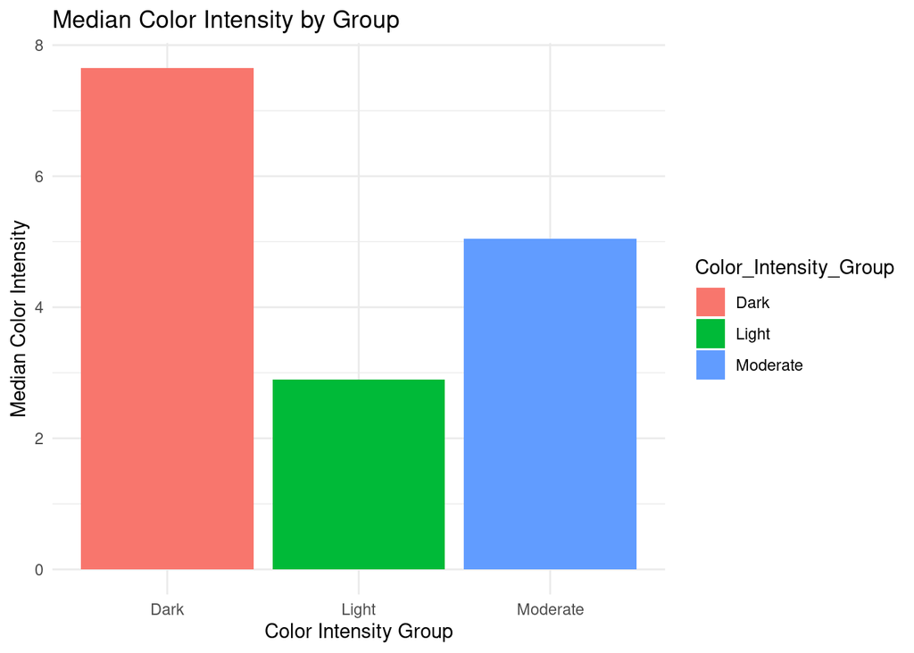

```r
# Color Intensity
ggplot(Median_Color_Intensity, aes(x = Color_Intensity_Group, y = Median_Color_Intensity, fill = Color_Intensity_Group)) +
  geom_bar(stat = "identity") +
  labs(title = "Median Color Intensity by Group", y = "Median Color Intensity", x = "Color Intensity Group") +
  theme_minimal()
```

# Q2- C: Interpretation of Bar Plots:

# 1. Alcohol_Level vs Median_Alcohol

# The median alcohol content increases progressively across the categories: Low → Medium → High.

# This gradient not only validates the categorical grouping but also highlights that wines with higher alcohol content tend to be fuller-bodied and more intense in flavor, aligning with typical wine classification standards.

# So it’s safe to sat that the grouping is effective for distinguishing wines by strength and potential consumer experience. Meaning stronger wines are likely to offer bolder profiles.

# 2. Ash_Content vs Median_Ash

# Median ash values also follow a logical trend: Low < Moderate < High.

# This suggests that the ash content classifications capture meaningful differences in mineral composition, which may influence mouthfeel and complexity.

# So it’s fair to conclude that Wines with higher ash content might be richer in mineral residues, potentially appealing to connoisseurs who appreciate structure and body in wines.

# 3. Color_Intensity_Group vs Median_Color_Intensity

# A clear increase in median color intensity is seen from Light to Dark, showing a strong visual and chemical correlation.

# Wines in the Dark group likely have higher phenolic content, which not only deepens color but also contributes to aging potential and astringency.

# So it is likely that the Color_Intensity_Group is particularly useful for identifying bold, age-worthy wines. Its alignment with numeric intensity values also support its reliability as a categorical variable.

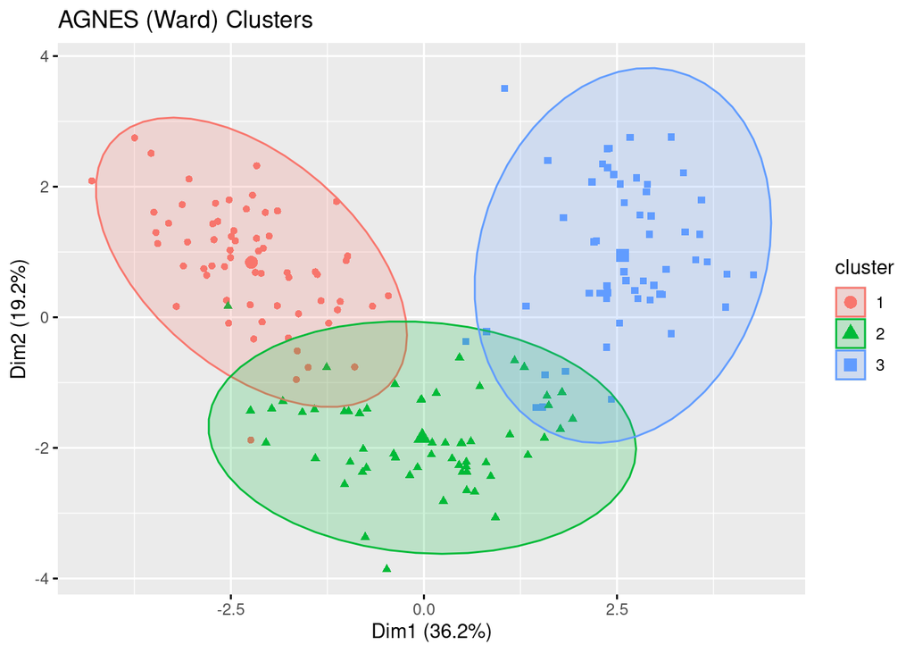

```r
# Q3-A:
# Clustering results:
Agnes_Cluster <- cutree(as.hclust(Agnes_Ward), k = 3)
Diana_Cluster <- cutree(as.hclust(Diana_Model), k = 3)

# Visualize clusters using PCA
fviz_cluster(list(data = Wine_Scaled, cluster = Agnes_Cluster),
             geom = "point", ellipse.type = "norm", main = "AGNES (Ward) Clusters")
```

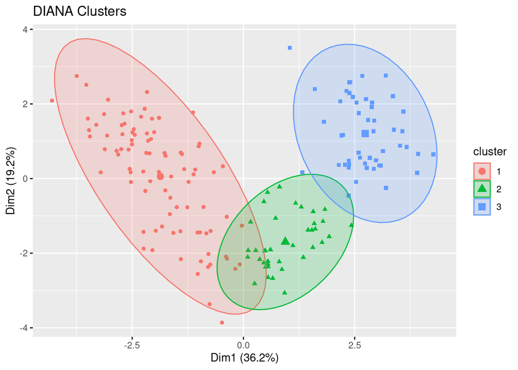

```r
fviz_cluster(list(data = Wine_Scaled, cluster = Diana_Cluster),
             geom = "point", ellipse.type = "norm", main = "DIANA Clusters")
```

# Most Appropriate Hierarchical Clustering Method:

# AGNES vs DIANA Comparison:

# AGNES with Ward’s method gave the highest agglomerative coefficient (AC) than DIANA’s divisive coefficient (DC), indicating a more cohesive cluster structure.

# Dendrogram Analysis:

# AGNES using Ward’s method produced three clean clusters with better separation.

# DIANA also identified cluster structure, but the separation is slighlty less pronounced.

# In Conclusion: AGNES with Ward’s method is more suitable for this dataset as it offers a more compact, interpretable clustering structure supported by higher cohesion metrics and clearer visual representation in the dendrogram.

# Q3-B:

# Alternative Clustering Techniques:

# K-Means:

# Could be useful due to its computational efficiency and effectiveness on well-separated, spherical clusters. However, it requires pre-specification of the number of clusters, which may not be ideal without prior knowledge.

# DBSCAN:

# Not ideal in this context because it is better suited for datasets with noise and non-globular clusters. The wine dataset is dense and continuous without many outliers, making DBSCAN less advantageous here.

# Recommendation: While K-Means might be acceptable with good initialization and an elbow method for k, hierarchical clustering (AGNES-Ward) remains the better choice due to its flexibility in exploring different cluster solutions without prior assumptions.